# Optimal Treatment Analysis

## Outcome Variable

**Outcome Variable:** haz

## Predictor Variables

**Intervention Variable:** vagbrth

**Adjustment Set:**

- arm
- sex
- W_mage
- meducyrs
- feducyrs
- hhwealth_quart
- W_mhtcm
- single
- brthmon
- W_parity
- delta_W_mage
- delta_meducyrs
- delta_feducyrs
- delta_hhwealth_quart
- delta_W_mhtcm
- delta_single
- delta_brthmon
- delta_W_parity

## Stratifying Variables

The analysis was stratified on these variable(s):

- agecat
- studyid
- country

## Data Summary

| agecat | studyid | country | vagbrth | n_cell | n |
| --- | --- | --- | --- | --- | --- |
| Birth | ki1000108-CMC-V-BCS-2002 | INDIA | 0 | 11 | 90 |
| Birth | ki1000108-CMC-V-BCS-2002 | INDIA | 1 | 79 | 90 |
| Birth | ki1000108-IRC | INDIA | 0 | 68 | 388 |
| Birth | ki1000108-IRC | INDIA | 1 | 320 | 388 |
| Birth | ki1017093c-NIH-Crypto | BANGLADESH | 0 | 1 | 19 |
| Birth | ki1017093c-NIH-Crypto | BANGLADESH | 1 | 18 | 19 |
| Birth | ki1119695-PROBIT | BELARUS | 0 | 1597 | 13884 |
| Birth | ki1119695-PROBIT | BELARUS | 1 | 12287 | 13884 |
| Birth | ki1126311-ZVITAMBO | ZIMBABWE | 0 | 1162 | 13716 |
| Birth | ki1126311-ZVITAMBO | ZIMBABWE | 1 | 12554 | 13716 |
| Birth | kiGH5241-JiVitA-3 | BANGLADESH | 0 | 3 | 19586 |
| Birth | kiGH5241-JiVitA-3 | BANGLADESH | 1 | 19583 | 19586 |
| Birth | kiGH5241-JiVitA-4 | BANGLADESH | 0 | 1 | 822 |
| Birth | kiGH5241-JiVitA-4 | BANGLADESH | 1 | 821 | 822 |
| 6 months | ki1000108-CMC-V-BCS-2002 | INDIA | 0 | 25 | 369 |
| 6 months | ki1000108-CMC-V-BCS-2002 | INDIA | 1 | 344 | 369 |
| 6 months | ki1000108-IRC | INDIA | 0 | 69 | 407 |
| 6 months | ki1000108-IRC | INDIA | 1 | 338 | 407 |
| 6 months | ki1017093b-PROVIDE | BANGLADESH | 0 | 134 | 583 |
| 6 months | ki1017093b-PROVIDE | BANGLADESH | 1 | 449 | 583 |
| 6 months | ki1017093c-NIH-Crypto | BANGLADESH | 0 | 187 | 457 |
| 6 months | ki1017093c-NIH-Crypto | BANGLADESH | 1 | 270 | 457 |
| 6 months | ki1066203-TanzaniaChild2 | TANZANIA, UNITED REPUBLIC OF | 0 | 189 | 2005 |
| 6 months | ki1066203-TanzaniaChild2 | TANZANIA, UNITED REPUBLIC OF | 1 | 1816 | 2005 |
| 6 months | ki1119695-PROBIT | BELARUS | 0 | 1799 | 15761 |
| 6 months | ki1119695-PROBIT | BELARUS | 1 | 13962 | 15761 |
| 6 months | ki1126311-ZVITAMBO | ZIMBABWE | 0 | 707 | 8228 |
| 6 months | ki1126311-ZVITAMBO | ZIMBABWE | 1 | 7521 | 8228 |
| 6 months | kiGH5241-JiVitA-3 | BANGLADESH | 0 | 1077 | 16732 |
| 6 months | kiGH5241-JiVitA-3 | BANGLADESH | 1 | 15655 | 16732 |
| 6 months | kiGH5241-JiVitA-4 | BANGLADESH | 0 | 336 | 4052 |
| 6 months | kiGH5241-JiVitA-4 | BANGLADESH | 1 | 3716 | 4052 |
| 24 months | ki1000108-CMC-V-BCS-2002 | INDIA | 0 | 25 | 372 |
| 24 months | ki1000108-CMC-V-BCS-2002 | INDIA | 1 | 347 | 372 |
| 24 months | ki1000108-IRC | INDIA | 0 | 69 | 409 |
| 24 months | ki1000108-IRC | INDIA | 1 | 340 | 409 |
| 24 months | ki1017093b-PROVIDE | BANGLADESH | 0 | 137 | 577 |
| 24 months | ki1017093b-PROVIDE | BANGLADESH | 1 | 440 | 577 |
| 24 months | ki1017093c-NIH-Crypto | BANGLADESH | 0 | 99 | 260 |
| 24 months | ki1017093c-NIH-Crypto | BANGLADESH | 1 | 161 | 260 |
| 24 months | ki1066203-TanzaniaChild2 | TANZANIA, UNITED REPUBLIC OF | 0 | 2 | 6 |
| 24 months | ki1066203-TanzaniaChild2 | TANZANIA, UNITED REPUBLIC OF | 1 | 4 | 6 |
| 24 months | ki1119695-PROBIT | BELARUS | 0 | 472 | 4035 |
| 24 months | ki1119695-PROBIT | BELARUS | 1 | 3563 | 4035 |
| 24 months | ki1126311-ZVITAMBO | ZIMBABWE | 0 | 29 | 450 |
| 24 months | ki1126311-ZVITAMBO | ZIMBABWE | 1 | 421 | 450 |
| 24 months | kiGH5241-JiVitA-3 | BANGLADESH | 0 | 480 | 8584 |
| 24 months | kiGH5241-JiVitA-3 | BANGLADESH | 1 | 8104 | 8584 |
| 24 months | kiGH5241-JiVitA-4 | BANGLADESH | 0 | 323 | 4020 |
| 24 months | kiGH5241-JiVitA-4 | BANGLADESH | 1 | 3697 | 4020 |

The following strata were considered:

- agecat: 24 months, studyid: ki1000108-CMC-V-BCS-2002, country: INDIA
- agecat: 24 months, studyid: ki1000108-IRC, country: INDIA
- agecat: 24 months, studyid: ki1017093b-PROVIDE, country: BANGLADESH
- agecat: 24 months, studyid: ki1017093c-NIH-Crypto, country: BANGLADESH
- agecat: 24 months, studyid: ki1066203-TanzaniaChild2, country: TANZANIA, UNITED REPUBLIC OF
- agecat: 24 months, studyid: ki1119695-PROBIT, country: BELARUS
- agecat: 24 months, studyid: ki1126311-ZVITAMBO, country: ZIMBABWE
- agecat: 24 months, studyid: kiGH5241-JiVitA-3, country: BANGLADESH
- agecat: 24 months, studyid: kiGH5241-JiVitA-4, country: BANGLADESH
- agecat: 6 months, studyid: ki1000108-CMC-V-BCS-2002, country: INDIA
- agecat: 6 months, studyid: ki1000108-IRC, country: INDIA
- agecat: 6 months, studyid: ki1017093b-PROVIDE, country: BANGLADESH
- agecat: 6 months, studyid: ki1017093c-NIH-Crypto, country: BANGLADESH
- agecat: 6 months, studyid: ki1066203-TanzaniaChild2, country: TANZANIA, UNITED REPUBLIC OF
- agecat: 6 months, studyid: ki1119695-PROBIT, country: BELARUS
- agecat: 6 months, studyid: ki1126311-ZVITAMBO, country: ZIMBABWE
- agecat: 6 months, studyid: kiGH5241-JiVitA-3, country: BANGLADESH
- agecat: 6 months, studyid: kiGH5241-JiVitA-4, country: BANGLADESH
- agecat: Birth, studyid: ki1000108-CMC-V-BCS-2002, country: INDIA
- agecat: Birth, studyid: ki1000108-IRC, country: INDIA
- agecat: Birth, studyid: ki1017093c-NIH-Crypto, country: BANGLADESH
- agecat: Birth, studyid: ki1119695-PROBIT, country: BELARUS
- agecat: Birth, studyid: ki1126311-ZVITAMBO, country: ZIMBABWE
- agecat: Birth, studyid: kiGH5241-JiVitA-3, country: BANGLADESH
- agecat: Birth, studyid: kiGH5241-JiVitA-4, country: BANGLADESH

### Dropped Strata

Some strata were dropped due to rare outcomes:

- agecat: Birth, studyid: ki1017093c-NIH-Crypto, country: BANGLADESH
- agecat: Birth, studyid: kiGH5241-JiVitA-3, country: BANGLADESH
- agecat: Birth, studyid: kiGH5241-JiVitA-4, country: BANGLADESH
- agecat: 24 months, studyid: ki1066203-TanzaniaChild2, country: TANZANIA, UNITED REPUBLIC OF

## Methods Detail

We’re interested in the causal parameters $E[Y_a]$ for all values of $a \in \mathcal{A}$. These parameters represent the mean outcome if, possibly contrary to fact, we intervened to set all units to have $A=a$. Under the randomization and positivity assumptions, these are identified by the statistical parameters $\psi_a=E_W[E_{Y|A,W}(Y|A=a,W)]$. In addition, we’re interested in the mean of $Y$, $E[Y]$ under no intervention (the observed mean). We will estimate these parameters by using SuperLearner to fit the relevant likelihood factors – $E_{Y|A,W}(Y|A=a,W)$ and $p(A=a|W)$, and then updating our likelihood fit using a joint TMLE.

For unadjusted analyses ($W=\{\}$), initial likelihoods were estimated using Lrnr_glm to estimate the simple $E(Y|A)$ and Lrnr_mean to estimate $p(A)$. For adjusted analyses, a small library containing Lrnr_glmnet, Lrnr_xgboost, and Lrnr_mean was used.

Having estimated these parameters, we will then use the delta method to estimate relative risks and attributable risks relative to a prespecified baseline level of $A$.

# Results Detail

## Results Plots

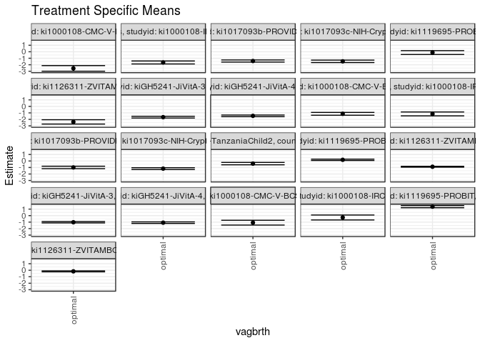

## Results Table

### Parameter: TSM

| agecat | studyid | country | intervention_level | baseline_level | estimate | ci_lower | ci_upper |
| --- | --- | --- | --- | --- | --- | --- | --- |
| Birth | ki1000108-CMC-V-BCS-2002 | INDIA | optimal | observed | -1.0851727 | -1.4538439 | -0.7165014 |
| Birth | ki1000108-IRC | INDIA | optimal | observed | -0.2882031 | -0.6687685 | 0.0923623 |
| Birth | ki1119695-PROBIT | BELARUS | optimal | observed | 1.3826721 | 1.2180273 | 1.5473169 |
| Birth | ki1126311-ZVITAMBO | ZIMBABWE | optimal | observed | -0.1719707 | -0.2467061 | -0.0972354 |
| 6 months | ki1000108-CMC-V-BCS-2002 | INDIA | optimal | observed | -1.1440031 | -1.3604884 | -0.9275178 |
| 6 months | ki1000108-IRC | INDIA | optimal | observed | -1.1603377 | -1.4584457 | -0.8622296 |
| 6 months | ki1017093b-PROVIDE | BANGLADESH | optimal | observed | -0.9915897 | -1.1813772 | -0.8018023 |
| 6 months | ki1017093c-NIH-Crypto | BANGLADESH | optimal | observed | -1.1731186 | -1.3127569 | -1.0334803 |
| 6 months | ki1066203-TanzaniaChild2 | TANZANIA, UNITED REPUBLIC OF | optimal | observed | -0.4030525 | -0.5858904 | -0.2202146 |
| 6 months | ki1119695-PROBIT | BELARUS | optimal | observed | 0.1845412 | 0.0822789 | 0.2868035 |
| 6 months | ki1126311-ZVITAMBO | ZIMBABWE | optimal | observed | -0.8840488 | -0.9493699 | -0.8187278 |
| 6 months | kiGH5241-JiVitA-3 | BANGLADESH | optimal | observed | -1.0214181 | -1.1271044 | -0.9157318 |
| 6 months | kiGH5241-JiVitA-4 | BANGLADESH | optimal | observed | -1.0840110 | -1.2046977 | -0.9633244 |
| 24 months | ki1000108-CMC-V-BCS-2002 | INDIA | optimal | observed | -2.5630183 | -2.9958447 | -2.1301920 |
| 24 months | ki1000108-IRC | INDIA | optimal | observed | -1.6474280 | -1.8751870 | -1.4196690 |
| 24 months | ki1017093b-PROVIDE | BANGLADESH | optimal | observed | -1.4245876 | -1.5886706 | -1.2605047 |
| 24 months | ki1017093c-NIH-Crypto | BANGLADESH | optimal | observed | -1.4732614 | -1.6616450 | -1.2848778 |
| 24 months | ki1119695-PROBIT | BELARUS | optimal | observed | -0.1205049 | -0.4183248 | 0.1773149 |
| 24 months | ki1126311-ZVITAMBO | ZIMBABWE | optimal | observed | -2.3880546 | -2.7215325 | -2.0545767 |
| 24 months | kiGH5241-JiVitA-3 | BANGLADESH | optimal | observed | -1.6573204 | -1.7948044 | -1.5198364 |
| 24 months | kiGH5241-JiVitA-4 | BANGLADESH | optimal | observed | -1.4603063 | -1.5884052 | -1.3322075 |

### Parameter: E(Y)

| agecat | studyid | country | intervention_level | baseline_level | estimate | ci_lower | ci_upper |
| --- | --- | --- | --- | --- | --- | --- | --- |
| Birth | ki1000108-CMC-V-BCS-2002 | INDIA | observed | observed | -0.9654444 | -1.1742112 | -0.7566777 |
| Birth | ki1000108-IRC | INDIA | observed | observed | -0.3080412 | -0.4687931 | -0.1472894 |
| Birth | ki1119695-PROBIT | BELARUS | observed | observed | 1.3254775 | 1.1669293 | 1.4840258 |
| Birth | ki1126311-ZVITAMBO | ZIMBABWE | observed | observed | -0.4977661 | -0.5184205 | -0.4771117 |
| 6 months | ki1000108-CMC-V-BCS-2002 | INDIA | observed | observed | -1.4234508 | -1.5645974 | -1.2823042 |
| 6 months | ki1000108-IRC | INDIA | observed | observed | -1.2344062 | -1.3658524 | -1.1029600 |
| 6 months | ki1017093b-PROVIDE | BANGLADESH | observed | observed | -1.0871041 | -1.1635539 | -1.0106543 |
| 6 months | ki1017093c-NIH-Crypto | BANGLADESH | observed | observed | -1.2731619 | -1.3626957 | -1.1836282 |
| 6 months | ki1066203-TanzaniaChild2 | TANZANIA, UNITED REPUBLIC OF | observed | observed | -0.5455565 | -0.5948696 | -0.4962435 |
| 6 months | ki1119695-PROBIT | BELARUS | observed | observed | 0.1069986 | 0.0122286 | 0.2017686 |
| 6 months | ki1126311-ZVITAMBO | ZIMBABWE | observed | observed | -0.8916778 | -0.9177946 | -0.8655610 |
| 6 months | kiGH5241-JiVitA-3 | BANGLADESH | observed | observed | -1.3134013 | -1.3366073 | -1.2901952 |
| 6 months | kiGH5241-JiVitA-4 | BANGLADESH | observed | observed | -1.3500888 | -1.3921730 | -1.3080047 |
| 24 months | ki1000108-CMC-V-BCS-2002 | INDIA | observed | observed | -2.5593683 | -2.6601027 | -2.4586339 |
| 24 months | ki1000108-IRC | INDIA | observed | observed | -1.7824776 | -1.8765600 | -1.6883952 |
| 24 months | ki1017093b-PROVIDE | BANGLADESH | observed | observed | -1.5861179 | -1.6693668 | -1.5028689 |
| 24 months | ki1017093c-NIH-Crypto | BANGLADESH | observed | observed | -1.5552692 | -1.6759022 | -1.4346363 |
| 24 months | ki1119695-PROBIT | BELARUS | observed | observed | -0.1314048 | -0.4282725 | 0.1654630 |
| 24 months | ki1126311-ZVITAMBO | ZIMBABWE | observed | observed | -2.3985333 | -2.5145993 | -2.2824674 |
| 24 months | kiGH5241-JiVitA-3 | BANGLADESH | observed | observed | -2.0134681 | -2.0411635 | -1.9857727 |
| 24 months | kiGH5241-JiVitA-4 | BANGLADESH | observed | observed | -1.7509129 | -1.7892403 | -1.7125856 |

### Parameter: PAR

| agecat | studyid | country | intervention_level | baseline_level | estimate | ci_lower | ci_upper |
| --- | --- | --- | --- | --- | --- | --- | --- |
| Birth | ki1000108-CMC-V-BCS-2002 | INDIA | optimal | observed | 0.1197282 | -0.1588728 | 0.3983293 |
| Birth | ki1000108-IRC | INDIA | optimal | observed | -0.0198381 | -0.3605834 | 0.3209071 |
| Birth | ki1119695-PROBIT | BELARUS | optimal | observed | -0.0571946 | -0.1310822 | 0.0166930 |
| Birth | ki1126311-ZVITAMBO | ZIMBABWE | optimal | observed | -0.3257954 | -0.3975251 | -0.2540656 |
| 6 months | ki1000108-CMC-V-BCS-2002 | INDIA | optimal | observed | -0.2794477 | -0.4807240 | -0.0781714 |
| 6 months | ki1000108-IRC | INDIA | optimal | observed | -0.0740686 | -0.3409149 | 0.1927778 |
| 6 months | ki1017093b-PROVIDE | BANGLADESH | optimal | observed | -0.0955143 | -0.2637767 | 0.0727481 |
| 6 months | ki1017093c-NIH-Crypto | BANGLADESH | optimal | observed | -0.1000433 | -0.2067272 | 0.0066405 |
| 6 months | ki1066203-TanzaniaChild2 | TANZANIA, UNITED REPUBLIC OF | optimal | observed | -0.1425040 | -0.3173289 | 0.0323209 |
| 6 months | ki1119695-PROBIT | BELARUS | optimal | observed | -0.0775426 | -0.1473644 | -0.0077207 |
| 6 months | ki1126311-ZVITAMBO | ZIMBABWE | optimal | observed | -0.0076290 | -0.0674660 | 0.0522081 |
| 6 months | kiGH5241-JiVitA-3 | BANGLADESH | optimal | observed | -0.2919832 | -0.3942994 | -0.1896670 |
| 6 months | kiGH5241-JiVitA-4 | BANGLADESH | optimal | observed | -0.2660778 | -0.3807319 | -0.1514237 |
| 24 months | ki1000108-CMC-V-BCS-2002 | INDIA | optimal | observed | 0.0036501 | -0.4022778 | 0.4095779 |
| 24 months | ki1000108-IRC | INDIA | optimal | observed | -0.1350496 | -0.3444877 | 0.0743885 |
| 24 months | ki1017093b-PROVIDE | BANGLADESH | optimal | observed | -0.1615302 | -0.3063018 | -0.0167587 |
| 24 months | ki1017093c-NIH-Crypto | BANGLADESH | optimal | observed | -0.0820078 | -0.2328258 | 0.0688101 |
| 24 months | ki1119695-PROBIT | BELARUS | optimal | observed | -0.0108999 | -0.2238792 | 0.2020795 |
| 24 months | ki1126311-ZVITAMBO | ZIMBABWE | optimal | observed | -0.0104787 | -0.3369340 | 0.3159765 |
| 24 months | kiGH5241-JiVitA-3 | BANGLADESH | optimal | observed | -0.3561477 | -0.4883768 | -0.2239186 |
| 24 months | kiGH5241-JiVitA-4 | BANGLADESH | optimal | observed | -0.2906066 | -0.4115544 | -0.1696588 |